# How Do Women in Political Power Differ in the U.S. Versus Across the Globe?

### December 9th, 2020

## Executive Summary

In this report, I wanted to explore gender inequality in the United States and around the world based on political representation. I gathered data from an online source that kept records for women in parliament for roughly 20 years. After analyzing the data, I found that the United States has a strong, linear relationship for growing female representation, but it will be a gradual process. In comparison, other regions like the European Union have a stabler and larger representation for women while South Asia has a weaker linear relationship. Overall, the globe is slowly but surely increasing its female representation in politics.

## Summary of Learning

This report was definitely an eye-opening experience. I learned a lot about how to search for efficient and interesting datasets because I initially had trouble deciding what kind of data I wanted to explore. I had some difficulty with the model evaluations, so I had to revisit the lectures to fully understand the models and what they represent. I definitely enjoyed this project because it allowed me the freedom to dive into data that truly matters to me, and I got to educated myself on the history of women in politics in so many different regions. Based on my findings, I believe that greater gender equality in politics is extremely important to dissolve traditional gender roles in the modern world.

## Dataset

Link to dataset: https://data.world/makeovermonday/2020w30

I used data from a csv in “data.world” that detailed gender inequality in the context of political appointments and parliamentary representation worldwide. The data was taken from 1997 to 2019, and the variables include the country names/codes, years, and proportion of seats held by women in national parliaments (%). I analyze the countries by grouping them together in regions, and then I compare them to each other. I also single the United States out to make some observations relevant to the state of gender inequality here.

## Exploratory Data Analysis

I first read in my data to their files.

```r
filepath <- "/Users/qianyuchen/Downloads"
setwd(filepath)
fulldataset <- read.csv("womeninpolitics1.csv")

#Selecting regions
unitedstates <- fulldataset[fulldataset$Country.Name == "United States", ]
middleeast <- fulldataset[fulldataset$Country.Code == "MEA", ]
eastasia_pacific <- fulldataset[fulldataset$Country.Name == "East Asia & Pacific", ]
europeanunion <- fulldataset[fulldataset$Country.Name == "European Union", ]
latin_caribbean <- fulldataset[fulldataset$Country.Code == "LCN", ]
southasia <- fulldataset[fulldataset$Country.Name == "South Asia", ]
subsaharan <- fulldataset[fulldataset$Country.Code == "SSF", ]

#Statistical summaries of the regions
summary(unitedstates)
```

```
##  Country.Name       Country.Code            Year        Proportion
##  Length:23          Length:23          Min.   :1997   Min.   :0.1172
##  Class :character   Class :character   1st Qu.:2002   1st Qu.:0.1443
##  Mode  :character   Mode  :character   Median :2008   Median :0.1678
##                                        Mean   :2008   Mean   :0.1679
##                                        3rd Qu.:2014   3rd Qu.:0.1887
##                                        Max.   :2019   Max.   :0.2350
##                                                       NA's   :1
```

```r
summary(middleeast)
```

```
##  Country.Name       Country.Code            Year        Proportion
##  Length:23          Length:23          Min.   :1997   Min.   :0.03604
##  Class :character   Class :character   1st Qu.:2002   1st Qu.:0.05886
##  Mode  :character   Mode  :character   Median :2008   Median :0.08353
##                                        Mean   :2008   Mean   :0.09862
##                                        3rd Qu.:2014   3rd Qu.:0.16012
##                                        Max.   :2019   Max.   :0.17085
```

```r
summary(europeanunion)
```

```
##  Country.Name       Country.Code            Year        Proportion
##  Length:23          Length:23          Min.   :1997   Min.   :0.1701
##  Class :character   Class :character   1st Qu.:2002   1st Qu.:0.2083
##  Mode  :character   Mode  :character   Median :2008   Median :0.2415
##                                        Mean   :2008   Mean   :0.2403
##                                        3rd Qu.:2014   3rd Qu.:0.2796
##                                        Max.   :2019   Max.   :0.3182
```

```r
summary(eastasia_pacific)
```

```
##  Country.Name       Country.Code            Year        Proportion
##  Length:23          Length:23          Min.   :1997   Min.   :0.1605
##  Class :character   Class :character   1st Qu.:2002   1st Qu.:0.1686
##  Mode  :character   Mode  :character   Median :2008   Median :0.1776
##                                        Mean   :2008   Mean   :0.1791
##                                        3rd Qu.:2014   3rd Qu.:0.1877
##                                        Max.   :2019   Max.   :0.2050
##                                                       NA's   :1
```

```r
summary(latin_caribbean)
```

```
##  Country.Name       Country.Code            Year        Proportion
##  Length:23          Length:23          Min.   :1997   Min.   :0.1313
##  Class :character   Class :character   1st Qu.:2002   1st Qu.:0.1729
##  Mode  :character   Mode  :character   Median :2008   Median :0.2216
##                                        Mean   :2008   Mean   :0.2198
##                                        3rd Qu.:2014   3rd Qu.:0.2661
##                                        Max.   :2019   Max.   :0.3167
```

```r
summary(southasia)
```

```
##  Country.Name       Country.Code            Year        Proportion
##  Length:23          Length:23          Min.   :1997   Min.   :0.05756
##  Class :character   Class :character   1st Qu.:2002   1st Qu.:0.09053
##  Mode  :character   Mode  :character   Median :2008   Median :0.15749
##                                        Mean   :2008   Mean   :0.14411
##                                        3rd Qu.:2014   3rd Qu.:0.19356
##                                        Max.   :2019   Max.   :0.20338
```

```r
summary(subsaharan)
```

```
##  Country.Name       Country.Code            Year        Proportion
##  Length:23          Length:23          Min.   :1997   Min.   :0.1021
##  Class :character   Class :character   1st Qu.:2002   1st Qu.:0.1397
##  Mode  :character   Mode  :character   Median :2008   Median :0.1813
##                                        Mean   :2008   Mean   :0.1810
##                                        3rd Qu.:2014   3rd Qu.:0.2238
##                                        Max.   :2019   Max.   :0.2408
##                                                       NA's   :1
```

I only want to focus on the “Proportion” variable, which explains the gender inequality present in that region. I can see that basically every region has a proportion of women in parliament of less than 0.5, which means there is still a significant inequality in politics around the globe. To understand how these regions’ proportions have changed over time, I plotted each region in a line graph.

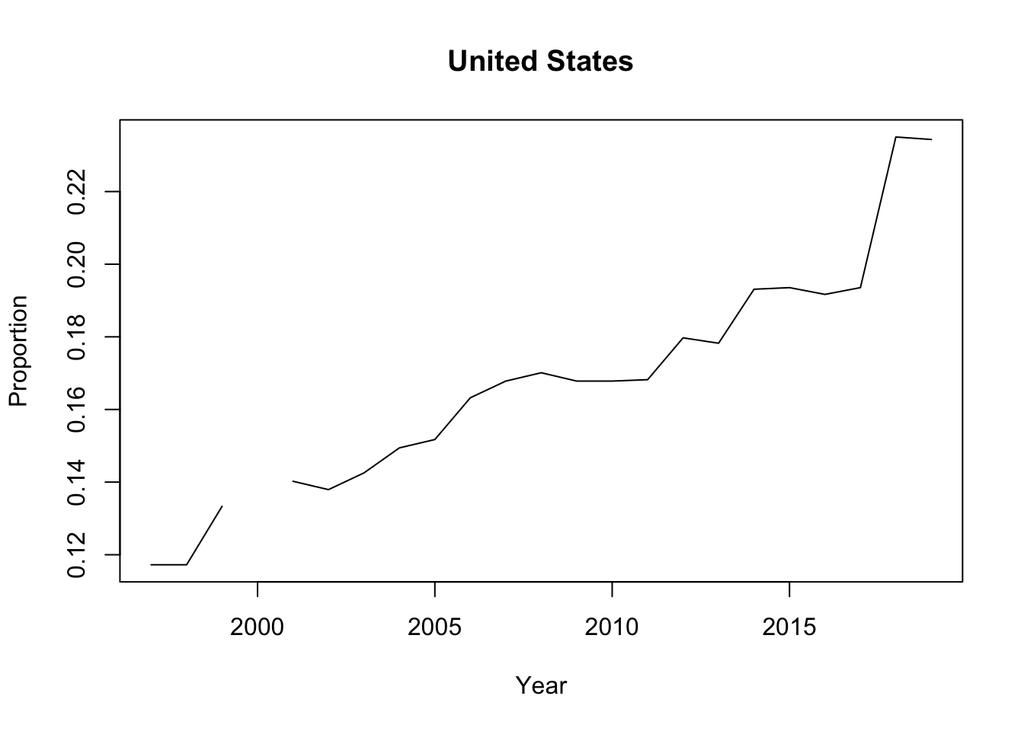

```r
plot(unitedstates$Year, unitedstates$Proportion, type = "l", xlab = "Year", ylab = "Proportion", main = "United States")
```

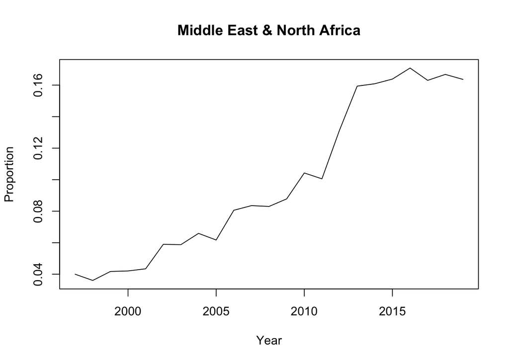

```r
plot(middleeast$Year, middleeast$Proportion, type = "l", xlab = "Year", ylab = "Proportion", main = "Middle East & North Africa")
```

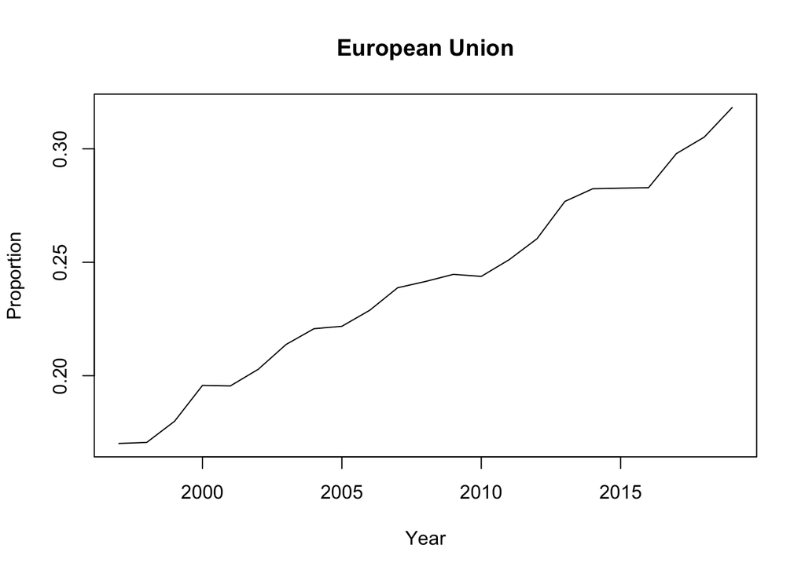

```r
plot(europeanunion$Year, europeanunion$Proportion, type = "l", xlab = "Year", ylab = "Proportion", main = "European Union")
```

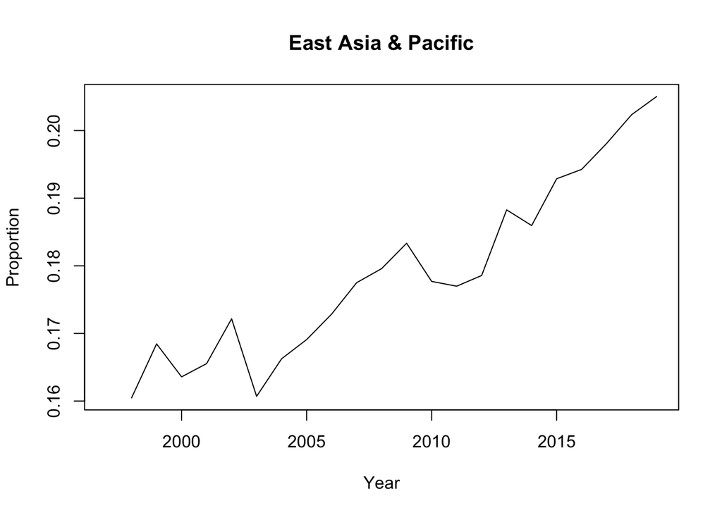

```r
plot(eastasia_pacific$Year, eastasia_pacific$Proportion, type = "l", xlab = "Year", ylab = "Proportion", main = "East Asia & Pacific")
```

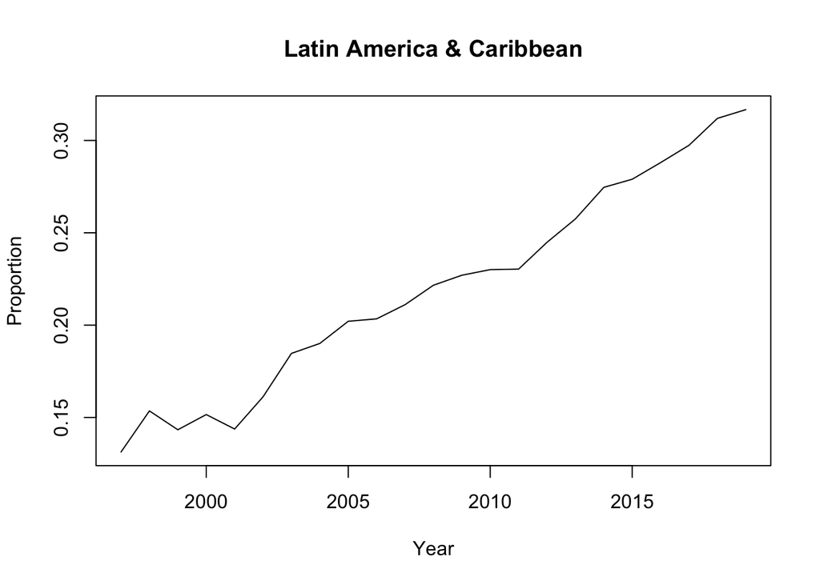

```r
plot(latin_caribbean$Year, latin_caribbean$Proportion, type = "l", xlab = "Year", ylab = "Proportion", main = "Latin America & Caribbean")
```

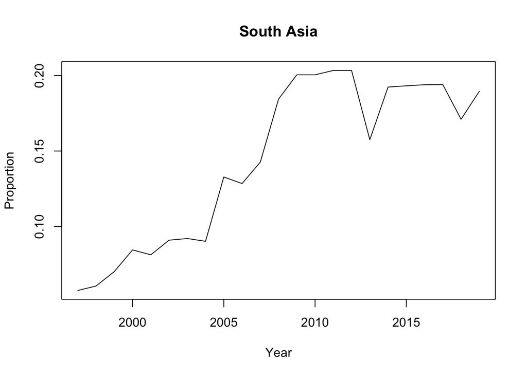

```r
plot(southasia$Year, southasia$Proportion, type = "l", xlab = "Year", ylab = "Proportion", main = "South Asia")
```

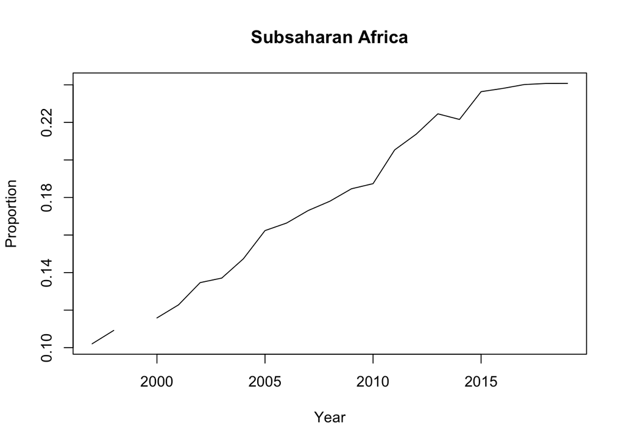

```r
plot(subsaharan$Year, subsaharan$Proportion, type = "l", xlab = "Year", ylab = "Proportion", main = "Subsaharan Africa")

library("ggplot2")
```

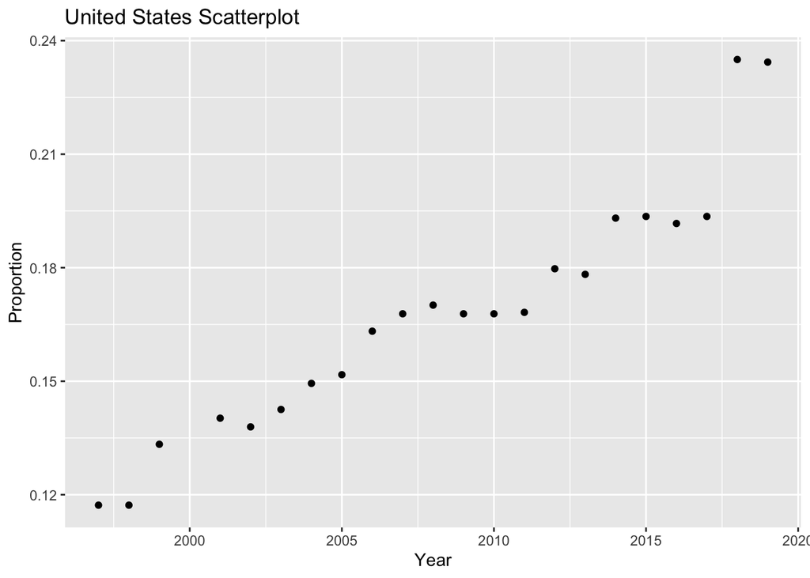

```r
ggplot(data = unitedstates) + geom_point(mapping = aes(x = Year, y = Proportion)) + ggtitle("United States Scatterplot")
```

## Models

To compare data, I chose two different regions to compare with the United States in terms of proportion of seats held by women in national parliaments (Proportion).

### The United States

I first trained a linear regression model with data from the United States.

```r
#Dividing as training and testing (20% test, 80% train) and getting the sample size
sample_size <- floor(0.8*nrow(unitedstates))
#Getting the index
train_ind <- sample(seq_len(nrow(unitedstates)), size = sample_size)
#Generating the train and test dataset
train <- unitedstates[train_ind,]
test <- unitedstates[-train_ind,]

#Going into the libraries
library("caret")
library("hydroGOF")
```

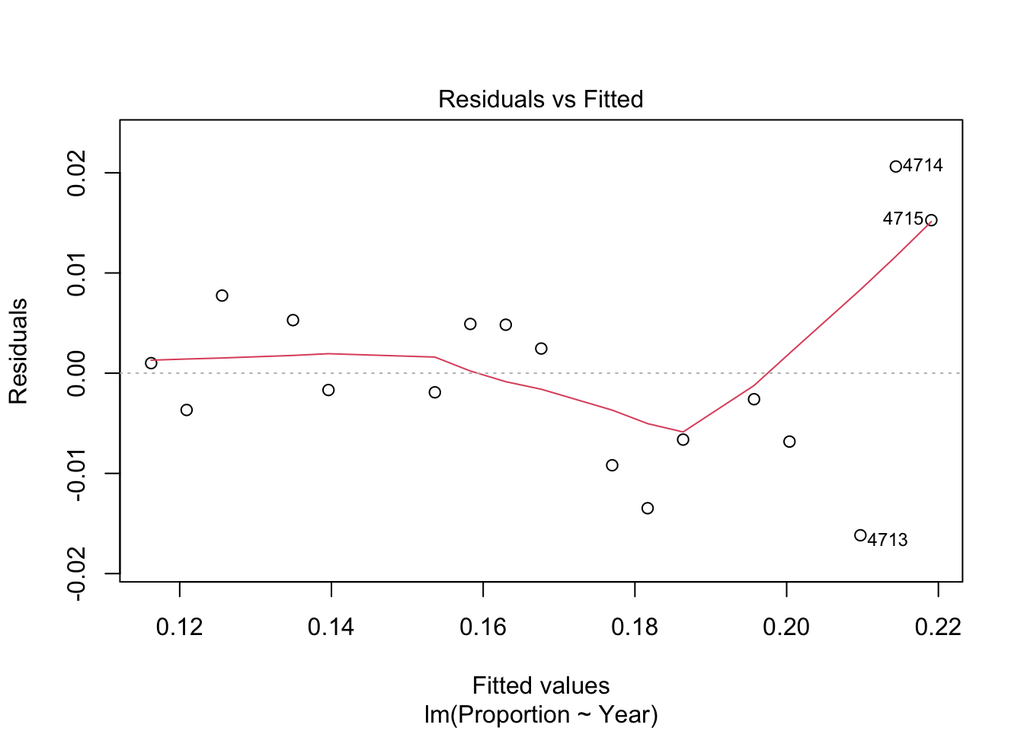

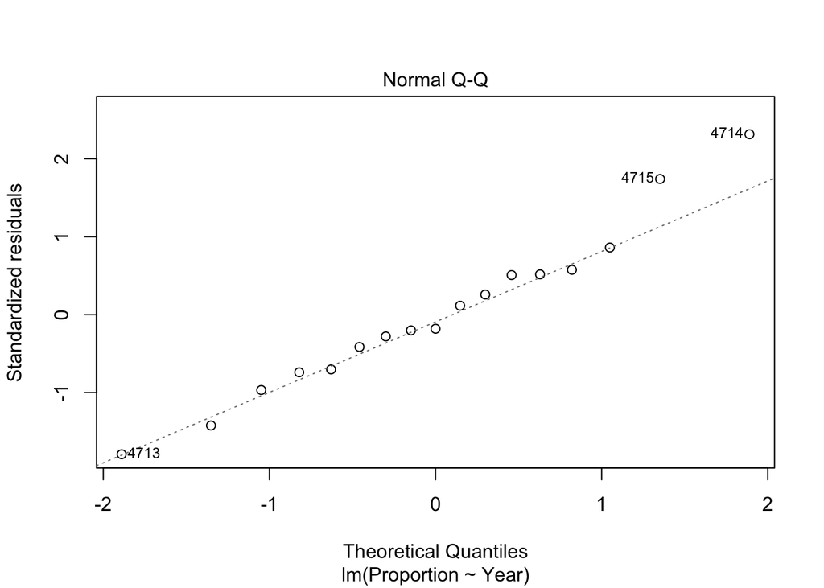

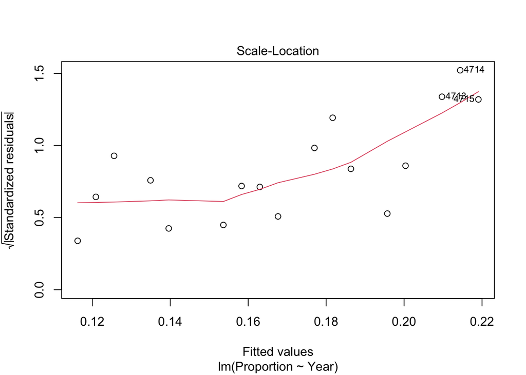

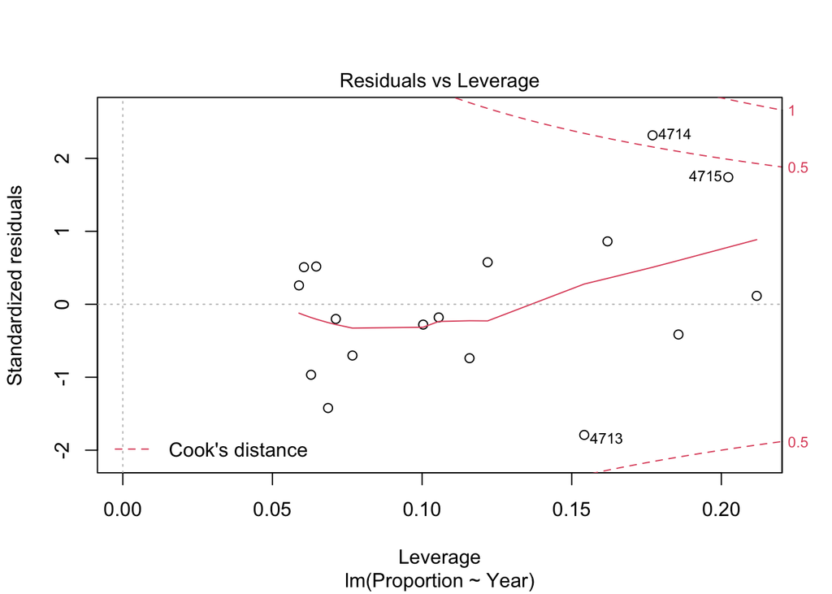

```r
#Training linear model using training data
model1 <- lm(Proportion ~ Year, data = train)
plot(model1)
```

```r
#Evaluating the model on test data
prediction <- predict(model1, newdata = test)
#Computing RMSE
rmse(prediction, test$Proportion, na.rm = TRUE)
```

```
## [1] 0.008552026
```

```r
#Testing correlation between predicted values and real values
cor.test(prediction, test$Proportion, use = "complete")
```

```
##
##  Pearson's product-moment correlation
##
## data:  prediction and test$Proportion
## t = 18.862, df = 3, p-value = 0.0003253
## alternative hypothesis: true correlation is not equal to 0
## 95 percent confidence interval:
##  0.9350550 0.9997374
## sample estimates:
##       cor
## 0.9958102
```

This model’s results show how close the R-squared is to one, meaning the data points fall almost perfectly on the regression line. The p-value is also quite small, so this relationship between Proportion and Year is linear.

### South Asia

Then, I made a 2nd model using data from South Asia.

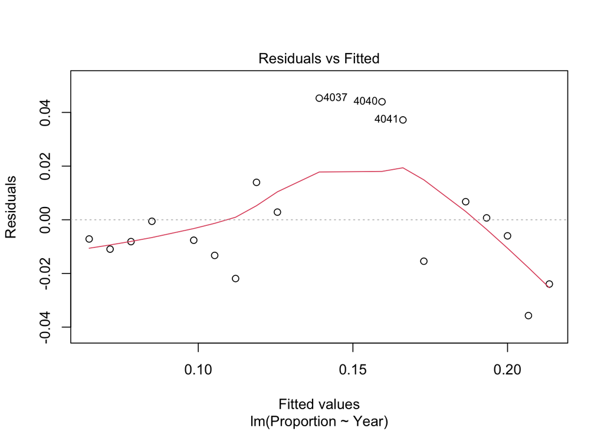

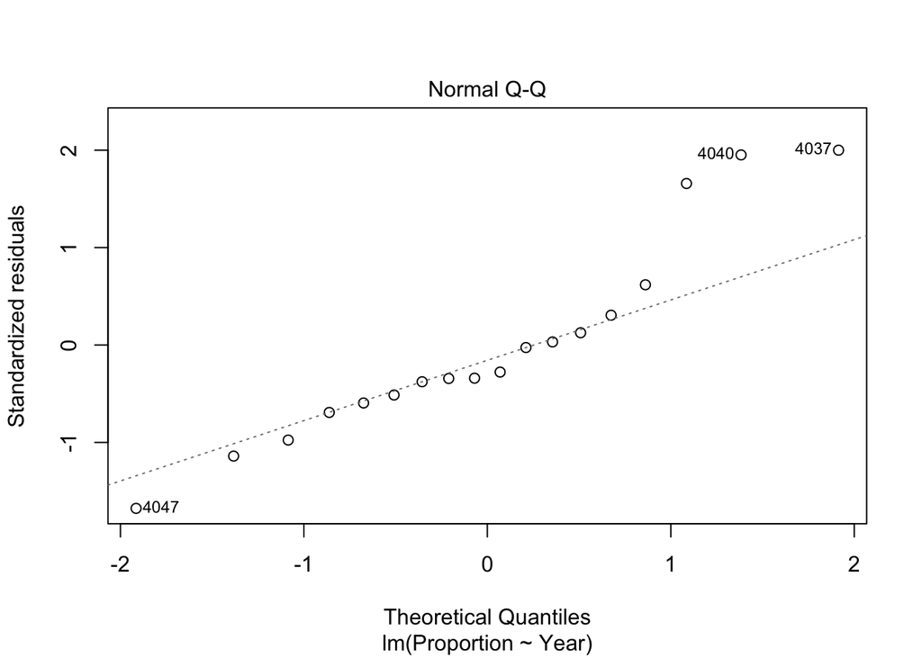

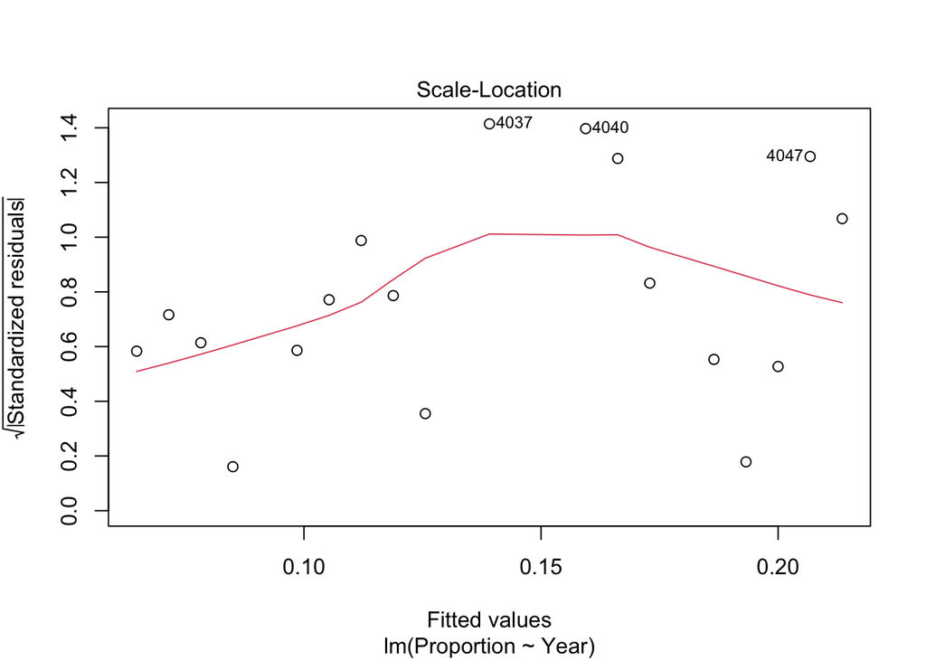

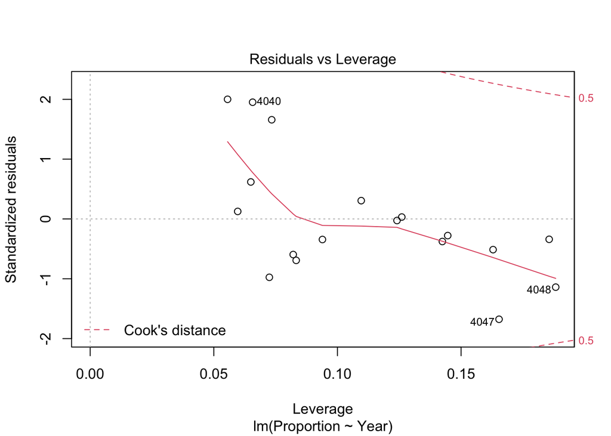

```r
#Dividing as training and testing (20% test, 80% train) and getting the sample size
sample_size <- floor(0.8*nrow(southasia))
#Getting the index
train_ind <- sample(seq_len(nrow(southasia)), size = sample_size)
#Generating the train and test dataset
train <- southasia[train_ind,]
test <- southasia[-train_ind,]

#Training linear model using training data
model2 <- lm(Proportion ~ Year, data = train)
plot(model2)
```

```r
#Evaluating the model on test data
prediction <- predict(model2, newdata = test)
#Computing RMSE
rmse(prediction, test$Proportion, na.rm = TRUE)
```

```
## [1] 0.03361733
```

```r
#Testing correlation between predicted values and real values
cor.test(prediction, test$Proportion, use = "complete")
```

```
##
##  Pearson's product-moment correlation
##
## data:  prediction and test$Proportion
## t = 3.3952, df = 3, p-value = 0.04261
## alternative hypothesis: true correlation is not equal to 0
## 95 percent confidence interval:
##  0.03978595 0.99280010
## sample estimates:
##       cor
## 0.8907842
```

For South Asia’s model, I found that the correlation coefficient was lower than the United States. This hints at a more random linear regression. The p-value is also higher, further showing how South Asia’s linear relationship between Proportion and Year is weaker.

### The European Union

Finally, I made a third model using data from the European Union.

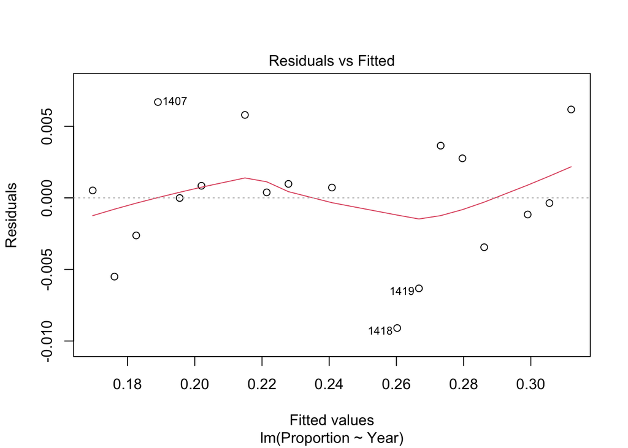

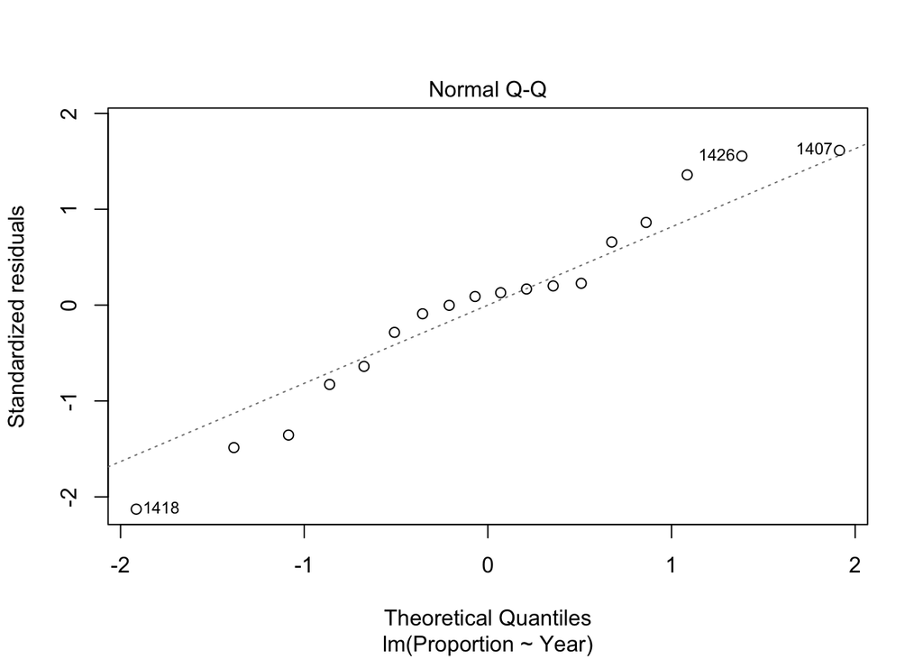

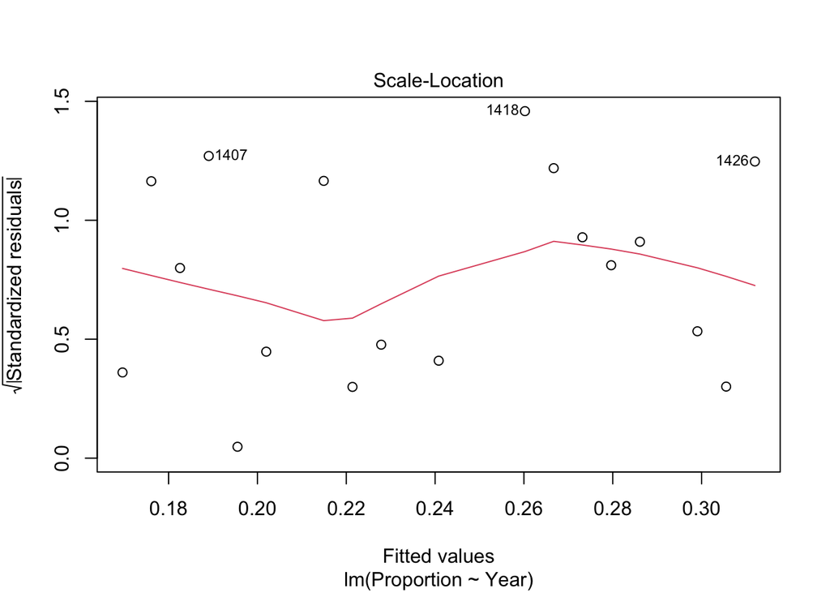

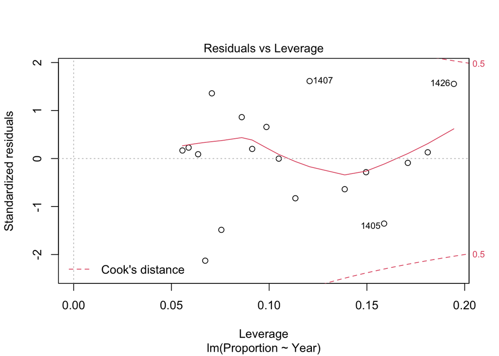

```r
#Dividing as training and testing (20% test, 80% train) and getting the sample size
sample_size <- floor(0.8*nrow(europeanunion))
#Getting the index
train_ind <- sample(seq_len(nrow(europeanunion)), size = sample_size)
#Generating the train and test dataset
train <- europeanunion[train_ind,]
test <- europeanunion[-train_ind,]

#Training linear model using training data
model3 <- lm(Proportion ~ Year, data = train)
plot(model3)
```

```r
#Evaluating the model on test data
prediction <- predict(model3, newdata = test)
#Computing RMSE
rmse(prediction, test$Proportion, na.rm = TRUE)
```

```
## [1] 0.007055269
```

```r
#Testing correlation between predicted values and real values
cor.test(prediction, test$Proportion, use = "complete")
```

```
##
##  Pearson's product-moment correlation
##
## data:  prediction and test$Proportion
## t = 10.891, df = 3, p-value = 0.001657
## alternative hypothesis: true correlation is not equal to 0
## 95 percent confidence interval:
##  0.8184493 0.9992191
## sample estimates:
##      cor
## 0.987588
```